# Showcase

A short showcase of one data visualisation and what it tells us.

## Overview

This page presents an example of my work in quantitative political analysis. It demonstrates how experimental data, statistical coding, and data visualisation can be used to explore questions in political communication and supporter engagement.

The example below is based on an A/B test examining whether issue-focused political messaging increases supporter signups.

## Research Question

Does an issue-focused homepage increase the probability that visitors sign up to support a political party?

To answer this question, website visitors are randomly assigned to one of two homepage versions: a standard control homepage or an issue-focused homepage. By comparing signup rates across these two groups, it becomes possible to estimate whether issue-focused messaging has a measurable effect on supporter engagement.

## Data

The analysis uses simulated A/B test data with **1,500 website visitors**. Each visitor is randomly assigned to either the control homepage or the issue-focused homepage.

The key outcome variable is `support_signup`, which records whether the visitor signs up as a supporter.

Because treatment is randomly assigned, differences between the two groups can be interpreted as the **causal effect** of the homepage design rather than simply a descriptive difference.

## Visualisation

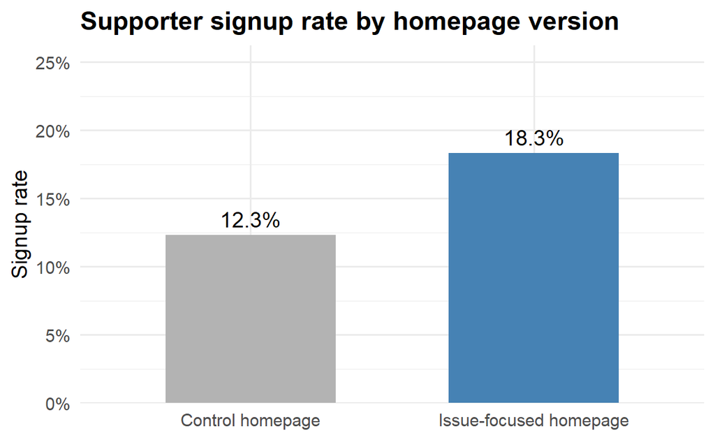

```r
# Set sample size
n <- 1500

# Random treatment assignment
treatment <- rbinom(n = n, size = 1, prob = 0.5)

# Potential outcomes
p_control <- 0.12
p_treated <- 0.17

Y0 <- rbinom(n = n, size = 1, prob = p_control)
Y1 <- rbinom(n = n, size = 1, prob = p_treated)

# Realised outcome
support_signup <- ifelse(treatment == 1, Y1, Y0)

# Data frame
party_ab <- data.frame(
  visitor_id = 1:n,
  treatment = treatment,
  support_signup = support_signup
)

# Group means
mean_control <- mean(party_ab$support_signup[party_ab$treatment == 0])
mean_treated <- mean(party_ab$support_signup[party_ab$treatment == 1])

means_df <- data.frame(
  treatment = c("Control homepage", "Issue-focused homepage"),
  mean_signup = c(mean_control, mean_treated)
)

# Bar plot
ggplot(means_df, aes(x = treatment, y = mean_signup, fill = treatment)) +
  geom_col(width = 0.6) +
  geom_text(
    aes(label = paste0(round(mean_signup * 100, 1), "%")),
    vjust = -0.5
  ) +
  scale_y_continuous(
    limits = c(0, 0.25),
    expand = expansion(mult = c(0, 0.05)),
    labels = percent_format(accuracy = 1)
  ) +
  scale_fill_manual(values = c("Control homepage" = "gray70",
                               "Issue-focused homepage" = "steelblue")) +
  labs(
    x = NULL,
    y = "Signup rate",
    title = "Supporter signup rate by homepage version"
  ) +
  theme_minimal(base_size = 14) +
  theme(
  legend.position = "none",
  plot.title = element_text(face = "bold")
)
```

## What the code does

The code simulates an A/B test where website visitors are randomly assigned to one of two homepage versions. It then generates the observed signup outcome for each visitor and calculates the average signup rate in both the control and treatment groups.

The final step creates a bar chart comparing the two group means, which makes it easy to see whether the issue-focused homepage appears to increase supporter signups.

## Interpretation

The figure compares the average signup rate between visitors shown the standard homepage and those shown the issue-focused homepage. The issue-focused homepage produces a higher signup rate than the control version, which suggests that highlighting a specific political issue can improve supporter engagement.

Because visitors are randomly assigned to treatment, the difference between the two groups can be interpreted as the causal effect of the homepage design. In practical terms, this suggests that issue-focused messaging may be more effective at converting website visitors into supporters.

## Limitation

One limitation is that the dataset is simulated rather than based on real campaign traffic. As a result, the findings may not fully capture the complexity of real political behaviour, where factors such as prior political interest, partisanship, or repeated exposure to campaign messaging may influence signup behaviour.

The analysis should therefore be interpreted as an illustration of experimental methods rather than definitive evidence about campaign strategy.

## Skills Demonstrated

This example highlights several quantitative skills:

- Experimental design and causal inference
- Simulation of experimental data
- Data handling and descriptive comparison
- Data visualisation using ggplot2
- Interpretation of treatment effects in political communication